# Apple iOS Mobile Applications Data Exploration

## Effects of Applications Features on the User Ratings

### Budhajit Roy Chanamthabam

## Investigation Overview

With the ever increasing uses of Mobile devices, the demand and competition for mobile applications have tremendously increased.

For this investigation, I'm exploring a dataset containing informations of around 7200 Apple iOS mobile application details that includes ratings given by the users and other related features and qualities.

## Dataset Overview

Dimensions of the data set: 7197 rows and 16 columns.

Features:

```
"id" : App ID
"track_name": App Name
"size_bytes": Size (in Bytes)
"currency": Currency Type
"price": Price amount
"rating_count_tot": User Rating counts (for all versions)
"rating_count_ver": User Rating counts (for current version)
"user_rating" : Average User Rating value (for all versions)
"user_rating_ver": Average User Rating value (for current version)
"ver" : Latest version code
"cont_rating": Content Rating
"prime_genre": Primary Genre
"sup_devices.num": Number of supporting devices
"ipadSc_urls.num": Number of screenshots showed for display
"lang.num": Number of supported languages
"vpp_lic": Vpp Device Based Licensing Enabled
```

### Distribution of User Ratings

1. There is a special peak at 0 and then a gap and then, a highly left skewed distribution of User Ratings for both current and Overall versions. We can somewhat observe that there are more number of higher ratings ranging from 4 to 5 compared to the lower ones. Also, the user rating data is a discrete data with values like 0, 0.5, 1, 1.5 ... 4.5, 5. It makes sense to have a gap of 0.5, as users normally doesn't give 0.5 as ratings.
2. The data distribution for the current user ratings and that for all versions are pretty similar with a very minimal increase of count in the rating 1 for current version user_rating as compared to rating 1 for all versions user_ratings.

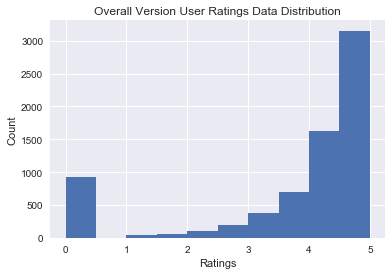

```python
# lets first look at our main feature of interest, the 'user_rating'
# user_rating : average user rating for all versions

plt.hist(data = appleStore, x = "user_rating");
plt.xlabel('Ratings');
plt.ylabel('Count');
plt.title('Overall Version User Ratings Data Distribution');
```

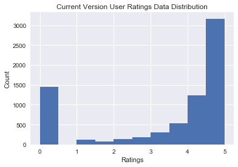

```python
# lets take a look at the data distribution for user_rating_ver
# user_rating_ver : average user rating for all versions

plt.hist(data = appleStore, x = "user_rating_ver");
plt.xlabel('Ratings');
plt.ylabel('Count');
plt.title('Current Version User Ratings Data Distribution');
```

### Distribution of Prices of the apps data

We can see that the distribution for "price" data is extremely right skewed, with almost all data range falling from 0 to 5 USD's and some few outliers data that is making the distribution highly skewed. We'll have to investigate more on these outliers and their possible impacts.

Also, there is a large amount of data values with price 0, I think these are the free applications.

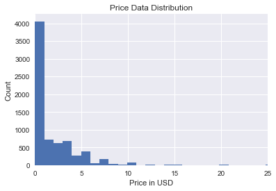

```python
# limiting the price values to 25 to get a detail view of the distribution
# putting the bin size to 0.99, as the price are in the descrete range 0, 0.99, 1.99 ..
bin_size = 0.99
bins_price = np.arange(0, 25+bin_size, bin_size)
plt.hist(data = appleStore, x = "price", bins = bins_price);
plt.xlim(0,25);
plt.xlabel('Price in USD');
plt.ylabel('Count');
plt.title('Price Data Distribution');
```

### Distribution of Sizes of the apps data

The size distribution data has also a very long tail towards right, with major portion of the spread lying between 0 to 400 MB when plotted normally. But plotted on log scale (as below), the size data distribution gives a more detail presentation and takes a modular shape with a peak value around 100 MB.

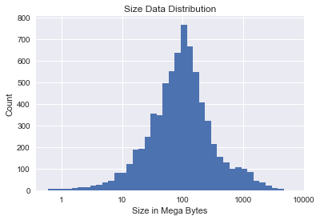

```python
# logarithmic presentation of the size data
bin_size = 0.1
bins = 10 **  np.arange(5.77, 9.6 + bin_size, bin_size)
plt.hist(data = appleStore, x = "size_bytes", bins = bins);
plt.xlabel('Size in Mega Bytes');
plt.xscale('log');
plt.ylabel('Count');
plt.xticks([1e6, 1e7, 1e8, 1e9, 1e10], ['1', '10', '100', '1000', '10000']);
plt.title('Size Data Distribution');
```

### Distribution of Different Genres of the Apps

The bar chart for the prime_genre of the apps says there is hugh dominancy of gaming apps in the app world, and then on the other side lies the rest of the genres leaded by Education and Entertainment.

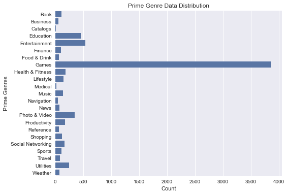

```python
# distribution for prime_genre
plt.figure(figsize = [8,6])
sb.countplot(data = appleStore, y = 'prime_genre', color = base_color)
plt.ylabel('Prime Genres');
plt.xlabel('Count');
plt.title('Prime Genre Data Distribution');
```

### Distribution of Content Rating Groups

More than half of the apps focused on lower age group users and those with the adult age groups (17+) with the fewest number of the apps.

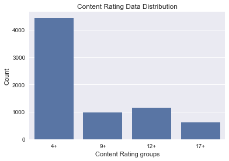

```python
# distribution for cont_rating
sb.countplot(data = appleStore, x = 'cont_rating', color = base_color)
plt.xlabel('Content Rating groups');
plt.ylabel('Count');
plt.title('Content Rating Data Distribution');
```

### Distribution of Number of Languages Supported by the Apps

The histogram shows that most of the apps falls between 0-7 number of supported languages, followed by a gradual decrease in the number of apps with increasing number of supporting languages. There are also some outliers with a very high number of supporting languages (which is not listed in the histogram below).

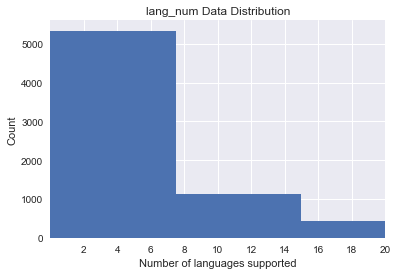

```python
# distribution for lang_num - limiting upto 20 counts only
plt.hist(data = appleStore, x = 'lang_num');
plt.xlabel('Number of languages supported');
plt.xlim([0,20]);
plt.xticks([2, 4, 6, 8, 10, 12, 14, 16, 18, 20], ['2', '4', '6', '8', '10','12', '14', '16', '18', '20']);
plt.ylabel('Count');
plt.title('lang_num Data Distribution');
```

### Created different Datasets for Free and Paid Apps.

For analyzing free and paid apps differently, I'm creating two datasets : One for Free and another for Paid.

### User Ratings on Free and Paid Apps

It appears that the user_ratings distributions (both current and all versions) for the apps are pretty similar irrespective of whether free or paid with major data around 4.5 user_ratings. The mean user ratings for overall versions for the paid apps is slightly lower than that of the free ones.

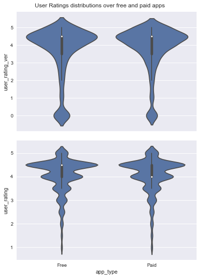

```python
# user rating distributions for the free and the paid apps.
def violin_plot(x, y, **kwargs):
    """ Quick hack for creating box plots with seaborn's PairGrid. """
    default_color = sb.color_palette()[0]
    sb.violinplot(x, y, color = default_color);

g = sb.PairGrid(data = temp, y_vars = ['user_rating_ver', 'user_rating'], x_vars = 'app_type',
                size = 4, aspect = 1.5);
g.map(violin_plot);
plt.subplots_adjust(top =0.95)
plt.suptitle('User Ratings distributions over free and paid apps');
plt.show();
```

### Current version and Overall Versions of the apps Ratings

The scatterplot between the user ratings for the overall version and the current version of the apps shows a somewhat strong positive relation for both the free and the paid apps.

The unusual 0 ratings for the current versions with a non-zero overall version ratings, I think seems that there is no rating listed by any of the users for these apps.

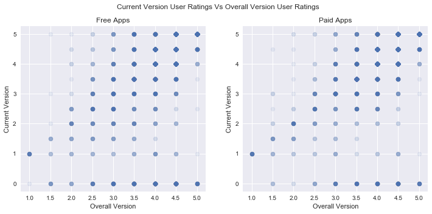

```python
# starting with the current version user ratings and the overall versions user ratings.
plt.figure(figsize = [12,5])

# left scatter plot for free apps
plt.subplot(1,2,1)
plt.scatter(data = free_apps, x = 'user_rating', y = 'user_rating_ver', alpha = 1/10)
plt.xlabel('Overall Version');
plt.ylabel('Current Version');
plt.title('Free Apps');

plt.subplot(1,2,2)
plt.scatter(data = paid_apps, x = 'user_rating', y = 'user_rating_ver', alpha = 1/10)
plt.xlabel('Overall Version');
plt.ylabel('Current Version');
plt.title('Paid Apps');

plt.suptitle('Current Version User Ratings Vs Overall Version User Ratings');
#https://stackoverflow.com/questions/7066121/how-to-set-a-single-main-title-above-all-the-subplots-with-pyplot
```

### Sizes impacts on User Ratings

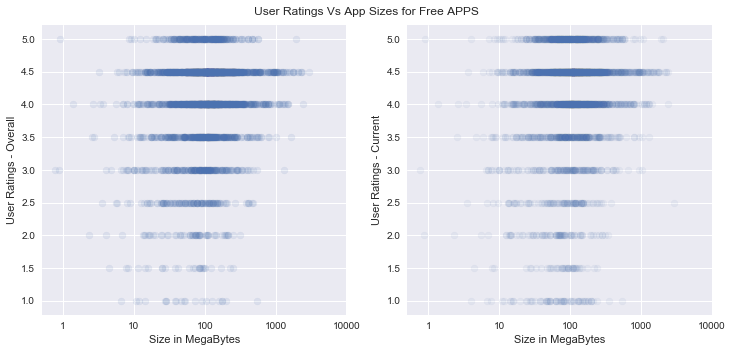

```python
# scatter plot of user ratings vs. size, with log transform on size axis for Free APPS
plt.figure(figsize = [12,5])

# left scatter plot for free apps
plt.subplot(1,2,1)
plt.scatter(data = free_apps, x = 'size_bytes', y = 'user_rating', alpha = 1/10);
plt.xlabel('Size in MegaBytes');
plt.xscale('log');
plt.xticks([1e6, 1e7, 1e8, 1e9, 1e10], ['1', '10', '100', '1000', '10000']);
plt.ylabel('User Ratings - Overall');

plt.subplot(1,2,2)
plt.scatter(data = free_apps_no_rating_ver, x = 'size_bytes', y = 'user_rating_ver', alpha = 1/15);
plt.xlabel('Size in MegaBytes');
plt.xscale('log');
plt.xticks([1e6, 1e7, 1e8, 1e9, 1e10], ['1', '10', '100', '1000', '10000']);
plt.ylabel('User Ratings - Current');
plt.subplots_adjust(top = 0.93)
plt.suptitle('User Ratings Vs App Sizes for Free APPS');
```

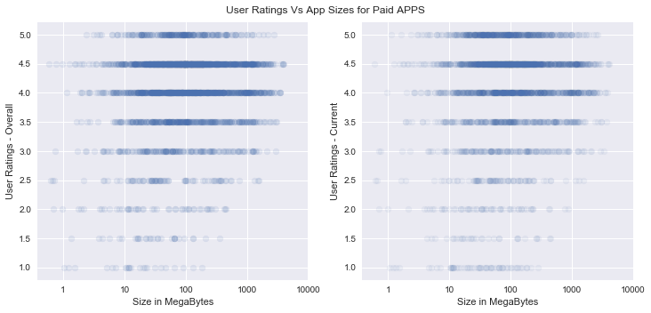

```python
# scatter plot of user ratings vs. size, with log transform on size axis for Paid APPS
plt.figure(figsize = [12,5])

# left scatter plot for free apps
plt.subplot(1,2,1)
plt.scatter(data = paid_apps, x = 'size_bytes', y = 'user_rating', alpha = 1/10);
plt.xlabel('Size in MegaBytes');
plt.xscale('log');
plt.xticks([1e6, 1e7, 1e8, 1e9, 1e10], ['1', '10', '100', '1000', '10000']);
plt.ylabel('User Ratings - Overall');

plt.subplot(1,2,2)
plt.scatter(data = paid_apps_no_rating_ver, x = 'size_bytes', y = 'user_rating_ver', alpha = 1/15);
plt.xlabel('Size in MegaBytes');
plt.xscale('log');
plt.xticks([1e6, 1e7, 1e8, 1e9, 1e10], ['1', '10', '100', '1000', '10000']);
plt.ylabel('User Ratings - Current');
plt.subplots_adjust(top = 0.93)
plt.suptitle('User Ratings Vs App Sizes for Paid APPS');
```

### Price impacts on User Ratings

More users tends to give more ratings on those apps with prices upto 10 USD, majorly with higher ratings values. And lesser count of ratings on apps higher than 10 USD. This is the only observation that I can made for the relation between Price and User Ratings.

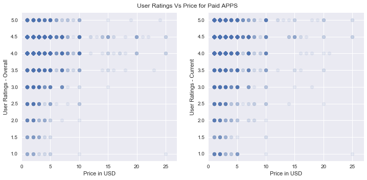

```python
# limiting the x axis price variable upto 25 USD only

plt.figure(figsize = [12,5])
plt.subplot(1,2,1)
plt.scatter(data = paid_apps, x = 'price', y = 'user_rating', alpha = 1/10);
plt.xlabel('Price in USD');
plt.xlim(0,27);
plt.ylabel('User Ratings - Overall');

plt.subplot(1,2,2)
plt.scatter(data = paid_apps_no_rating_ver, x = 'price', y = 'user_rating_ver', alpha = 1/10);
plt.xlabel('Price in USD');
plt.xlim(0,27);
plt.ylabel('User Ratings - Current');
plt.subplots_adjust(top = 0.93)
plt.suptitle('User Ratings Vs Price for Paid APPS');
```

### Content Ratings Vs Prime Genres

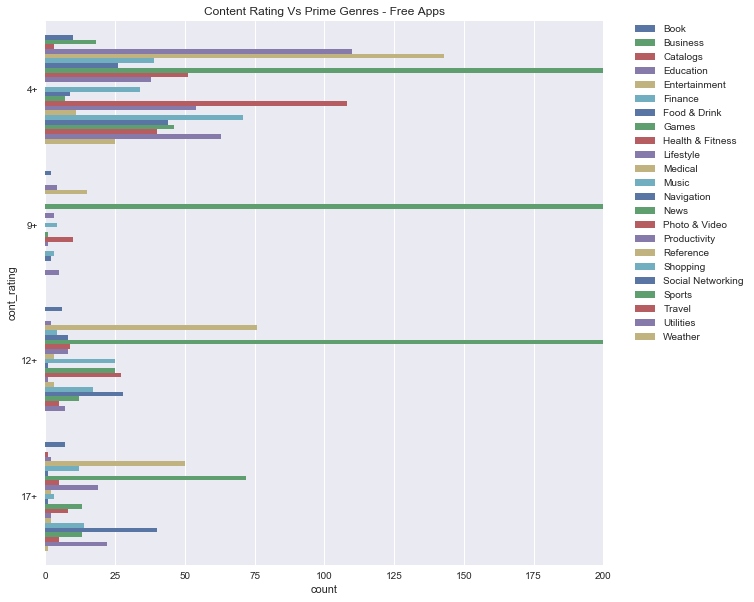

```python
# lets limit the count to 200 to get a more detailed distribution

plt.figure(figsize = [10,10]);
set_color = sb.color_palette();
ax = sb.countplot(data = free_apps, y = 'cont_rating', hue = 'prime_genre',palette=set_color);
ax.legend(loc = 5, framealpha = 1)
plt.xlim(0,200);
plt.legend(bbox_to_anchor=(1.05, 1), loc=2, borderaxespad=0.); # legend outside the plot
plt.title('Content Rating Vs Prime Genres - Free Apps');
```

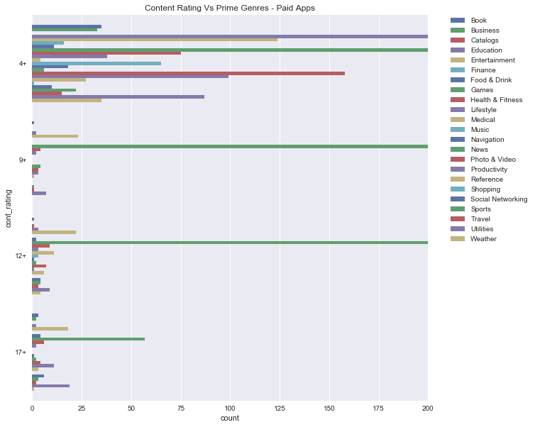

```python
# lets limit the count to 200 to get a more detailed distribution
plt.figure(figsize = [10,10]);
set_color = sb.color_palette();
ax = sb.countplot(data = paid_apps, y = 'cont_rating', hue = 'prime_genre',palette=set_color);
ax.legend(loc = 5, framealpha = 1)
plt.legend(bbox_to_anchor=(1.05, 1), loc=2, borderaxespad=0.)
plt.xlim(0,200);
plt.title('Content Rating Vs Prime Genres - Paid Apps');
```

### User Ratings by Prime Genres and Content Ratings groups.

Unexpectedly I can see a much clearer impacts on user ratings by the two categoric variables than the numeric variables (price and size that I initially thought). So, for paid apps following observations can be made:

- For 4+ groups, shopping, book and references have a stronger relation with higher user ratings.
- Book, Education, Health & Fitness, Games, Photo & Video and News are stronger in 9+ groups.
- Books, Catalogs, Education, Food & Drink, Travel, Navigation, Games and Health & Fitness are strong.
- While for 17+, Books, Business, Lifestyle, Navigation, News, Photo & Video, Travel and Weather are pretty strong.

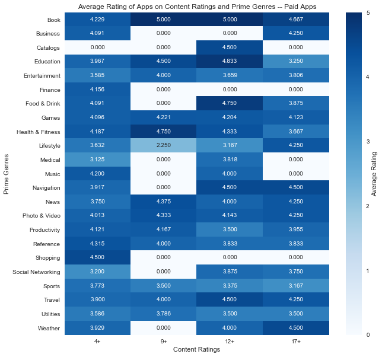

```python
#creating the heatmap for paid apps
#https://python-graph-gallery.com/92-control-color-in-seaborn-heatmaps/ -- changing colors heatmap
plt.figure(figsize = [10,10])
sb.heatmap(temp1_paid, annot = True, fmt = '.3f',cmap="Blues", cbar_kws = {'label':'Average Rating'});
plt.xlabel('Content Ratings');
plt.ylabel('Prime Genres');
plt.title('Average Rating of Apps on Content Ratings and Prime Genres -- Paid Apps');
```

Similarly for free apps:

- I can see Health & Fitness, Productivity, Reference forms a stronger relation with higher user ratings in 4+ groups.
- Books, Games, Lifestyle, Social Networking, Shopping and Utilities are the most popular in 9+ groups.
- Book, Games, Medical, Navigation, Photo & Video, Productivity, Shopping and Utilities are for 12+ groups.
- Lastly in 17+ groups, Book, Catalogs, Education, Food & Drink and Medical are the most popular ones.

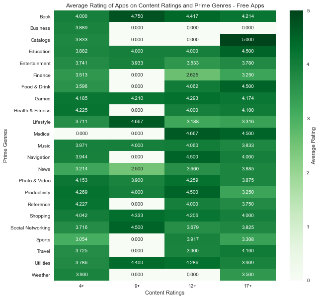

```python
#creating the heatmap for free apps
#https://python-graph-gallery.com/92-control-color-in-seaborn-heatmaps/ -- changing colors heatmap
plt.figure(figsize = [10,10])
sb.heatmap(temp1_free, annot = True, fmt = '.3f',cmap="Greens", cbar_kws = {'label':'Average Rating'});
plt.xlabel('Content Ratings');
plt.ylabel('Prime Genres');
plt.title('Average Rating of Apps on Content Ratings and Prime Genres - Free Apps');
```

### User Ratings on Total Count and Content Rating Groups.

For Paid apps group, I can say that users on average gives higher ratings to apps around 3.5 to 4.5 as compared to the lower ratings since, in the above plot we can see, the mean of the total ratings counts for the higher ratings are generally higher than those of the lower ratings.

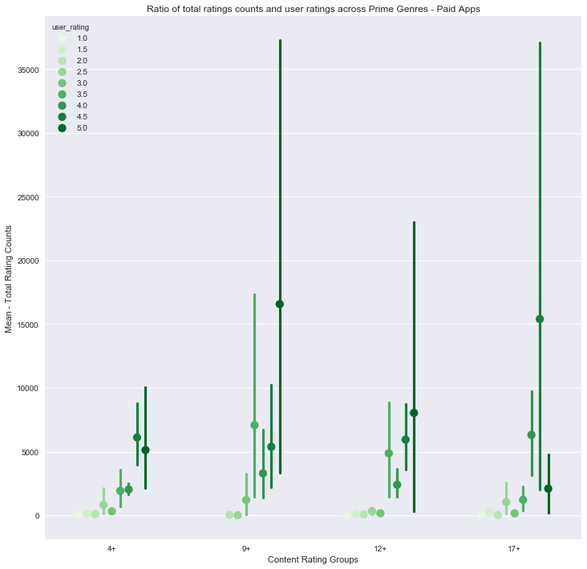

```python
# Ratio of the total rating counts and the user ratings - Paid apps group.
fig = plt.figure(figsize = [12,12])
ax = sb.pointplot(data = paid_apps, x = 'cont_rating', y = 'rating_count_tot', hue = 'user_rating',
           palette = 'Greens', linestyles = '', dodge = 0.5)
plt.title('Ratio of total ratings counts and user ratings across Prime Genres - Paid Apps')
plt.ylabel('Mean - Total Rating Counts')
plt.xlabel('Content Rating Groups')
plt.show()
```

Unexpectedly for Free apps, users on average gives variant ratings across the apps of different content rating groups. 4+ groups gaves on average more ratings of 3.5, 4.5 and 5. 9+ groups on average gave more ratings of 3 and 4.5. 12+ with 2.5, 4 and 4.5 ratings and lastly 17+ groups gives 2, 2.5, 3.5, 4.5 and 5 user ratings on average.

[figure not shown]

```python
# Ratio of the total rating counts and the user ratings - Free apps group.
fig = plt.figure(figsize = [12,12])
ax = sb.pointplot(data = free_apps, x = 'cont_rating', y = 'rating_count_tot', hue = 'user_rating',
           palette = 'Greens', linestyles = '', dodge = 0.5)
plt.title('Ratio of total ratings counts and user ratings across Prime Genres - Paid Apps')
plt.ylabel('Mean - Total Rating Counts')
plt.xlabel('Content Rating Groups')
plt.show()
```